# swirl Lesson 5: Base Plotting System

The first plot should be familiar. Plot airquality$Wind and airquality$Ozone with the title (argument main) as “Ozone and Wind”.

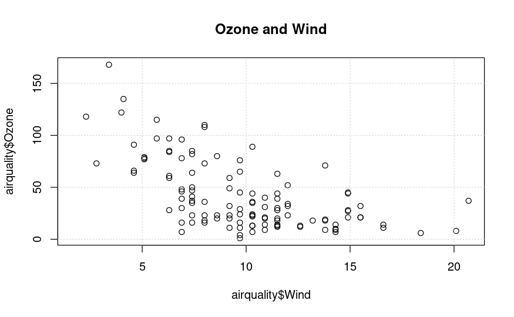

```r
plot(airquality$Wind, airquality$Ozone, main="Ozone and Wind")
grid()
```

The second plot is similar.

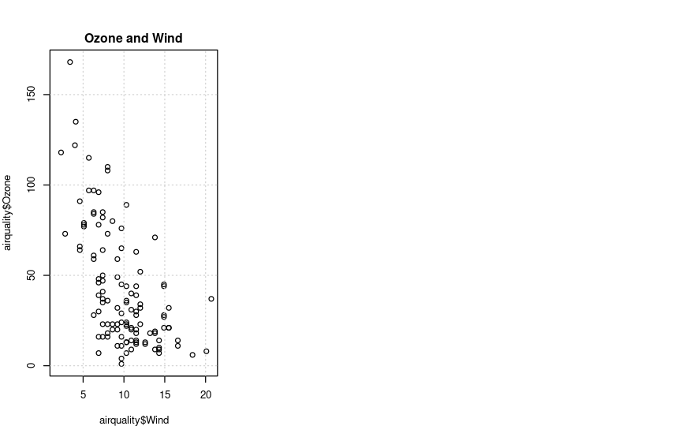

```r
try(dev.off(), silent=TRUE)
par(mfrow = c(1, 3), mar=c(4, 4, 2, 1), oma=c(0, 0, 2, 0))
plot(airquality$Wind, airquality$Ozone, main="Ozone and Wind")
grid()
```

Plot airquality$Solar.R and airquality$Ozone with the title (argument main) as “Ozone and Solar Radiation”.

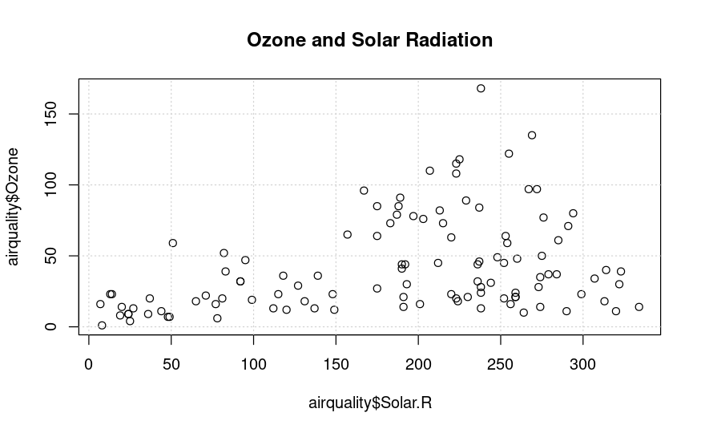

```r
plot(airquality$Solar.R, airquality$Ozone, main="Ozone and Solar Radiation")
grid()
```

Now for the final panel.

```r
try(dev.off(), silent=TRUE)
par(mfrow=c(1, 3), mar=c(4, 4, 2, 1), oma=c(0, 0, 2, 0))
plot(airquality$Wind, airquality$Ozone, main="Ozone and Wind")
grid()
```

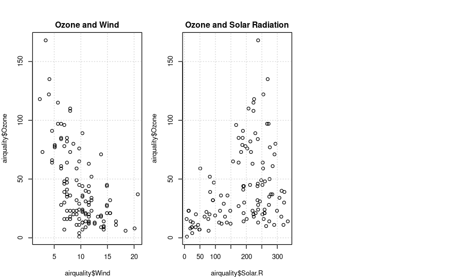

```r
plot(airquality$Solar.R, airquality$Ozone, main="Ozone and Solar Radiation")
grid()
```

Plot airquality$Temp and airquality$Ozone with the title (argument main) as “Ozone and Temperature”.

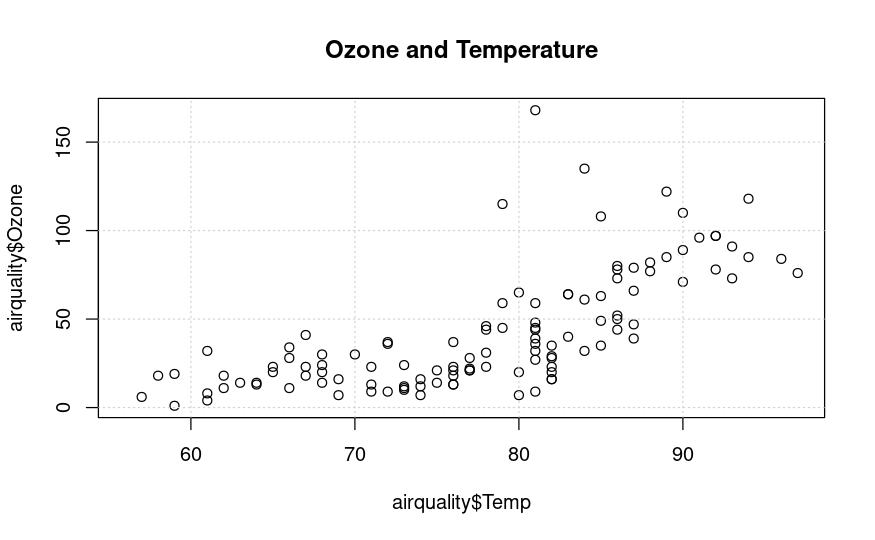

```r
plot(airquality$Temp, airquality$Ozone, main="Ozone and Temperature")
grid()
```

Now we’ll put in a title.

```r
try(dev.off(),silent=TRUE)
par(mfrow=c(1, 3), mar=c(4, 4, 2, 1), oma=c(0, 0, 2, 0))
plot(airquality$Wind, airquality$Ozone, main="Ozone and Wind")
grid()
```

```r
plot(airquality$Solar.R, airquality$Ozone, main="Ozone and Solar Radiation")
grid()
```

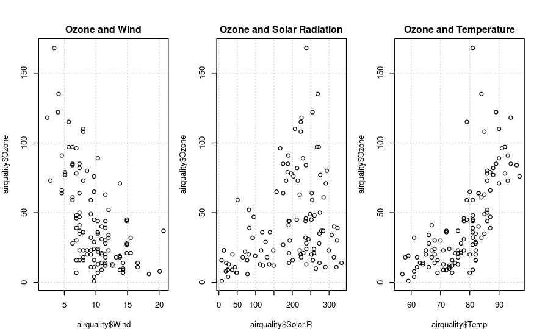

```r
plot(airquality$Temp, airquality$Ozone, main="Ozone and Temperature")
grid()
```

Since this is the main title, we specify it with the R command mtext. Call mtext with the string “Ozone and Weather in New York City” and the argument outer set equal to TRUE.

```r
try(dev.off(), silent=TRUE)
par(mfrow=c(1, 3), mar=c(4, 4, 2, 1), oma=c(0, 0, 2, 0))
plot(airquality$Wind, airquality$Ozone, main="Ozone and Wind")
grid()
```

```r
plot(airquality$Solar.R, airquality$Ozone, main="Ozone and Solar Radiation")
grid()
```

```r
plot(airquality$Temp, airquality$Ozone, main="Ozone and Temperature")
grid()
```

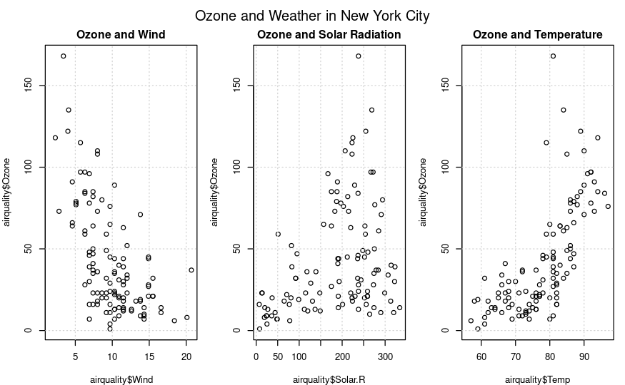

```r
mtext("Ozone and Weather in New York City", outer=TRUE)
```

Voila! Beautiful, right?